# REPRODUCIBLE RESEARCH

## Peer asessment 1

### Project Objective

Answer some exploratoty analisys questions about a given dataset.

### Loading and preprocessing the data

Downloading raw data from given url:

```r
setwd("C:/Users/pc/Documents/R/Rep_research/work")
unzip("repdata-data-activity.zip")
```

```r
data <- read.csv("activity.csv")
#temp <- tempfile()
#download.file("https://d396qusza40orc.cloudfront.net/repdata%2Fdata%2Factivity.zip",temp)
#data <- read.csv(unz(temp, "activity.csv"))
#unlink(temp)
```

### What is mean total number of steps taken per day?

Calculate the total number of steps taken per day

```r
library(data.table)
data_sum <- setDT(data)[, sum(steps, na.rm = TRUE), by=date]
data_sum
```

```
##           date    V1
##  1: 2012-10-01     0
##  2: 2012-10-02   126
##  3: 2012-10-03 11352
##  4: 2012-10-04 12116
##  5: 2012-10-05 13294
##  6: 2012-10-06 15420
##  7: 2012-10-07 11015
##  8: 2012-10-08     0
##  9: 2012-10-09 12811
## 10: 2012-10-10  9900
## 11: 2012-10-11 10304
## 12: 2012-10-12 17382
## 13: 2012-10-13 12426
## 14: 2012-10-14 15098
```

[output cut: 48 more lines]

Histogram of the total number of steps taken each day

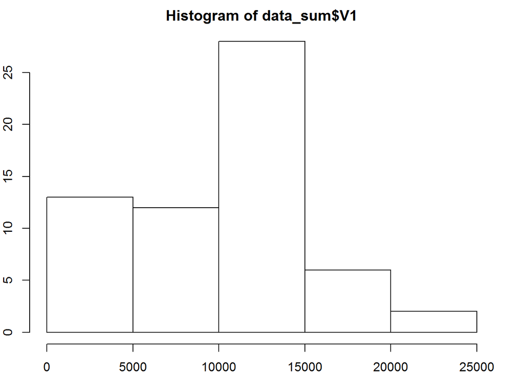

```r
par(mar = rep(2, 4))
hist(data_sum$V1)
```

```r
data_mean <- setDT(data)[, mean(steps, na.rm = TRUE), by=date]
data_mean
```

```
##           date         V1
##  1: 2012-10-01        NaN
##  2: 2012-10-02  0.4375000
##  3: 2012-10-03 39.4166667
##  4: 2012-10-04 42.0694444
##  5: 2012-10-05 46.1597222
##  6: 2012-10-06 53.5416667
##  7: 2012-10-07 38.2465278
##  8: 2012-10-08        NaN
##  9: 2012-10-09 44.4826389
## 10: 2012-10-10 34.3750000
## 11: 2012-10-11 35.7777778
## 12: 2012-10-12 60.3541667
## 13: 2012-10-13 43.1458333
## 14: 2012-10-14 52.4236111
```

[output cut: 48 more lines]

### What is the average daily activity pattern?

Make a time series plot (i.e. type = “l”) of the 5-minute interval (x-axis) and the average number of steps taken, averaged across all days (y-axis)

```r
data_avg <- setDT(data)[, mean(steps, na.rm = TRUE), by=interval]
data_avg
```

```
##      interval        V1
##   1:        0 1.7169811
##   2:        5 0.3396226
##   3:       10 0.1320755
##   4:       15 0.1509434
##   5:       20 0.0754717
##  ---
## 284:     2335 4.6981132
## 285:     2340 3.3018868
## 286:     2345 0.6415094
## 287:     2350 0.2264151
## 288:     2355 1.0754717
```

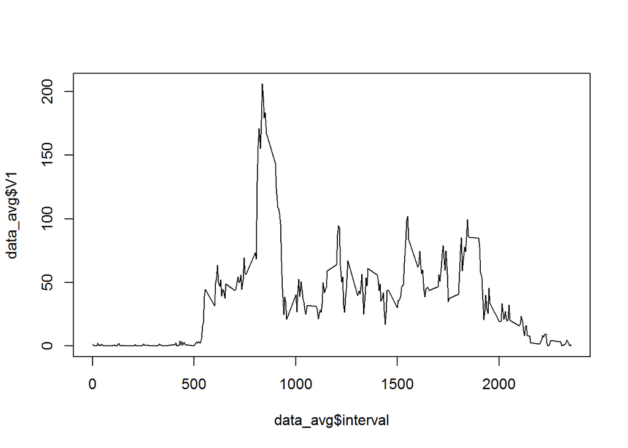

```r
plot(data_avg$interval,data_avg$V1,type="l")
```

Which 5-minute interval, on average across all the days in the dataset, contains the maximum number of steps? Intervals between id810 and 920 have higher averages (more than 100 steps), top value is locaed in interval 835 (206 steps avg)

### Imputing missing values

Calculate and report the total number of missing values in the dataset (i.e. the total number of rows with NAs)

```r
sum(is.na(data$steps))
```

```
## [1] 2304
```

Devise a strategy for filling in all of the missing values in the dataset. The strategy does not need to be sophisticated. For example, you could use the mean/median for that day, or the mean for that 5-minute interval, etc.

```r
data2 <- data
data2$steps[which(is.na(data2$steps))] <- mean(data2$steps, na.rm = TRUE)
```

Replace na´s for column mean

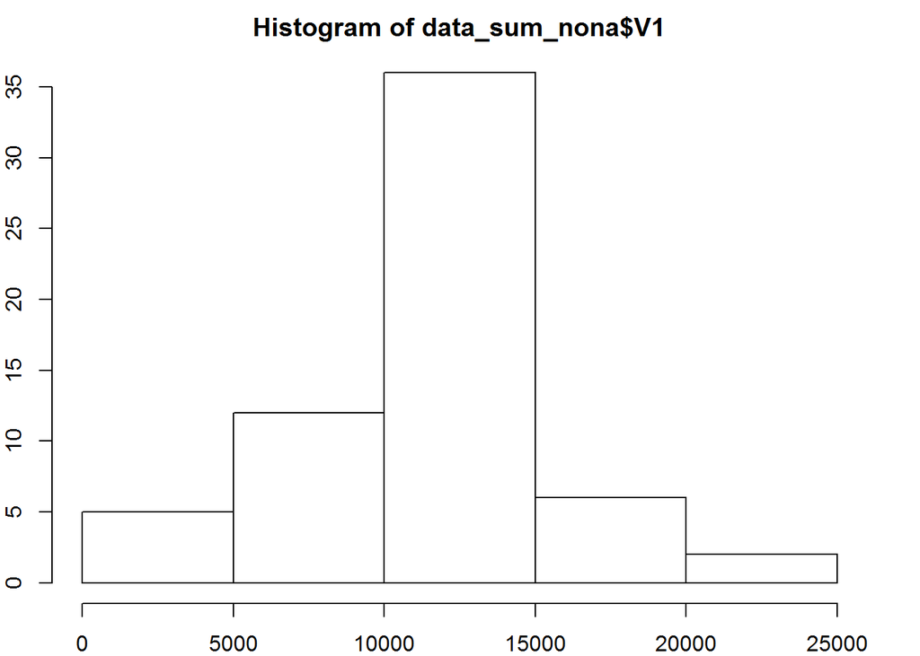

```r
data_sum_nona <- setDT(data2)[, sum(steps, na.rm = TRUE), by=date]
par(mar = rep(2, 4))
hist(data_sum_nona$V1)
```

```r
data_mean_nona <- setDT(data2)[, mean(steps, na.rm = TRUE), by=date]
data_mean_nona
```

```
##           date         V1
##  1: 2012-10-01 37.3825996
##  2: 2012-10-02  0.4375000
##  3: 2012-10-03 39.4166667
##  4: 2012-10-04 42.0694444
##  5: 2012-10-05 46.1597222
##  6: 2012-10-06 53.5416667
##  7: 2012-10-07 38.2465278
##  8: 2012-10-08 37.3825996
##  9: 2012-10-09 44.4826389
## 10: 2012-10-10 34.3750000
## 11: 2012-10-11 35.7777778
## 12: 2012-10-12 60.3541667
## 13: 2012-10-13 43.1458333
## 14: 2012-10-14 52.4236111
```

[output cut: 48 more lines]

### Are there differences in activity patterns between weekdays and weekends?

Create a new factor variable in the dataset with two levels - “weekday” and “weekend” indicating whether a given date is a weekday or weekend day.

```r
data2$days <- as.factor(weekdays(as.Date(data2$date)))
levels(data2$days)
```

```
## [1] "domingo"   "jueves"    "lunes"     "martes"    "miércoles" "sábado"
## [7] "viernes"
```

```r
levels(data2$days) <- c("Weekend", "Weekday", "Weekday", "Weekday", "Weekday", "Weekend", "Weekday")
levels(data2$days)
```

```
## [1] "Weekend" "Weekday"
```

Make a panel plot containing a time series plot (i.e. type = “l”) of the 5-minute interval (x-axis) and the average number of steps taken, averaged across all weekday days or weekend days (y-axis). See the README file in the GitHub repository to see an example of what this plot should look like using simulated data.

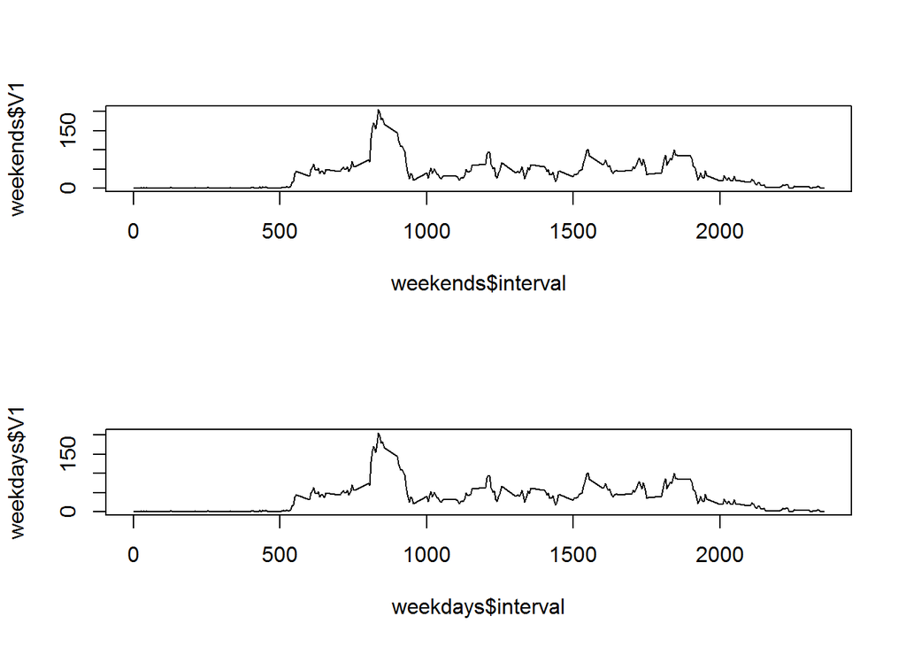

```r
data3 <- merge(data2, data_avg, by = "interval", all.x = TRUE)
weekends <- subset(data3, days == "Weekend")
weekdays <- subset(data3, days == "Weekday")
par(mfrow=c(2,1))
plot(weekends$interval,weekends$V1,type="l")
plot(weekdays$interval,weekdays$V1,type="l")
```